# Уровень каких белков различается в мышиной модели синдрома Дауна

29 02 2020

Загрузка необходимых пакетов

```r
knitr::opts_chunk$set(echo = TRUE)
library(readxl)
library(ggplot2)
library(dunn.test)
library(multcomp)
library(pca3d)
library(vegan)
library(car)
```

Для загрузки датасета воспользуемся функцией read_excel из пакета **readxl**

```r
nucl <- read_excel('C:/Users/Alexandra Dolgikh/Downloads/Data_Cortex_Nuclear.xls')
```

Как мы видим, в таблице у нас содержится 1080 измерений значений различных белков и некоторая классификация для групп, на которые можно подразделить данные этих измерений. Как становится ясно из описания датасета у нас существует 8 классов мышей, в которых комбинируются различные условия. Во-первых, это наличие или отсутствие у мышей трисомии в локусах, затрагивающих гены, ассоциированные с синдромом Дауна. В этом случае мыши делятся на Control и мутантную линию Ts65Dn. Также существовало деление мышей на группы в зависимости от того, когда на них было оказано шоковое воздействие посредством электрического тока. Группа context-shock(CS) сначала была помещена на 3 минуты в новое помещение, а уже потом было осуществлено воздействие электрическим током, а для группы shock-context все было сделано ровно наоброт. Также мыши были поделены на группы, которым вводили инъекции либо мемантина, либо соляного раствора. Таким образом, всего в эксперименте был исследовано 8 классов.

Всего в эксперименте участвовали 72 мыши, 38 из них обозначены как контрольные, а 34 содержат трисомию. Для каждой мыши интересующие белки были измерены в 15-кратной повторности.

Оценим количество наблюдений в разных классах.

```r
table(nucl$class)
```

```
##
## c-CS-m c-CS-s c-SC-m c-SC-s t-CS-m t-CS-s t-SC-m t-SC-s
##    150    135    150    135    135    105    135    135
```

Видим, что количество измерений в разных классах несбалансированно, потому что для каждого биологического образца(соответсвующего данным с одной мыши)было проведено 15 технических измерений, а здесь цифры не равны.

Для того, чтобы определить количество наблюдений, для которых данные являются является полными по всем белкам, воспользуемся следующей функцией

```r
sum(complete.cases(nucl))
```

```
## [1] 552
```

Как мы видим лишь половина наблюдений являются полными.

## Различия в уровне продукции BDNF_N в зависимости от класса

Теперь, оценим уровень продукции белка **BDNF_N** в зависимости от класса

Для начала проверим, сколько в векторе соответствующем данному белку пропущенных значений

```r
sum(is.na(nucl$BDNF_N))
```

```
## [1] 3
```

Видим, что пропущенных значений всего три. С учетом 1080 значений 3 это немного, поэтому в данном случае заменим NA на среднее и сразу проверим, что пропущенных значений теперь нет

```r
nucl$BDNF_N[is.na(nucl$BDNF_N)]<-mean(nucl$BDNF_N,na.rm=T)
sum(is.na(nucl$BDNF_N))
```

```
## [1] 0
```

Оценим, как распределены данные по классам

```r
BDNF <- nucl[,c("BDNF_N","class")]
table(BDNF$class)
```

```
##
## c-CS-m c-CS-s c-SC-m c-SC-s t-CS-m t-CS-s t-SC-m t-SC-s
##    150    135    150    135    135    105    135    135
```

Как мы видим, количество наблюдений по продукции данного белка в разных классах также не равно (что по сути понятно и из того, что у нас в целом разное количество мышей в разных классах)

Теперь с использованием вывода функции fortify и пакета ggplot построим график расстояний кука для оценки наличия влиятельных наблюдений

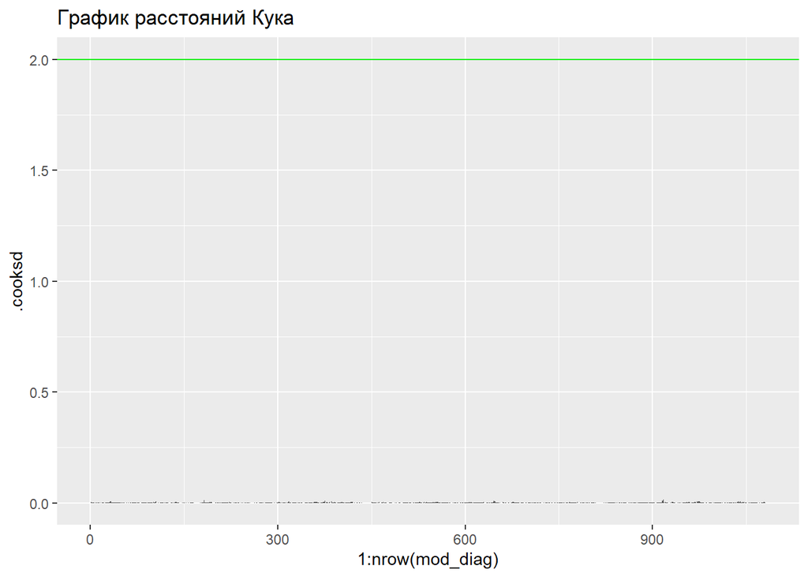

Влиятельных наблюдений мы не видим. Посмотрим также, есть ли разброс в дисперсии остатков.

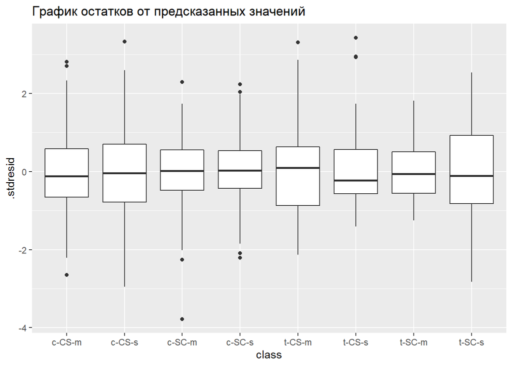

```r
ggplot(mod_diag, aes(x = class, y = .stdresid)) + geom_boxplot() + ggtitle("График остатков от предсказанных значений")
```

Как мы видим, разброс в дисперсии все же есть и поскольку у нас группы не сбалансированы по количеству наблюдений, мы все же воспользуемся непараметрическим аналогом ANOVA - тестом Краскелла-Уоллиса.

```r
kruskal.test(BDNF_N ~ class, data = nucl)
```

```
##
##  Kruskal-Wallis rank sum test
##
## data:  BDNF_N by class
## Kruskal-Wallis chi-squared = 121.08, df = 7, p-value < 2.2e-16
```

Видим, что значение p-value значимо меньше 0.05, а значит между классами существует разница в экспрессии гена BDNF_N

В качестве пост-хок теста используем Dunn test

```r
dunn.test(nucl$BDNF_N,nucl$class,method = 'bonferroni')
```

```
##   Kruskal-Wallis rank sum test
##
## data: x and group
## Kruskal-Wallis chi-squared = 121.0753, df = 7, p-value = 0
##
##
##                            Comparison of x by group
##                                  (Bonferroni)
## Col Mean-|
## Row Mean |     c-CS-m     c-CS-s     c-SC-m     c-SC-s     t-CS-m     t-CS-s
## ---------+------------------------------------------------------------------
##   c-CS-s |  -0.143309
##          |     1.0000
##   c-SC-m |   8.653957   8.566453
##          |    0.0000*    0.0000*
##   c-SC-s |   4.205015   4.238223  -4.218127
##          |    0.0004*    0.0003*    0.0003*
##   t-CS-m |   4.524504   4.549622  -3.898639   0.311398
##          |    0.0001*    0.0001*    0.0014*     1.0000
##   t-CS-s |   6.017658   6.015209  -1.835679   2.050714   1.759428
##          |    0.0000*    0.0000*     0.9297     0.5641     1.0000
##   t-SC-m |   3.031556   3.094476  -5.391587  -1.143746  -1.455145  -3.120591
##          |     0.0341     0.0276    0.0000*     1.0000     1.0000     0.0253
##   t-SC-s |   2.330523   2.411194  -6.092619  -1.827028  -2.138427  -3.759744
##          |     0.2769     0.2226    0.0000*     0.9477     0.4547    0.0024*
## Col Mean-|
## Row Mean |     t-SC-m
## ---------+-----------
##   t-SC-s |  -0.683282
##          |     1.0000
##
## alpha = 0.05
## Reject Ho if p <= alpha/2
```

Визуализируем полученные данные

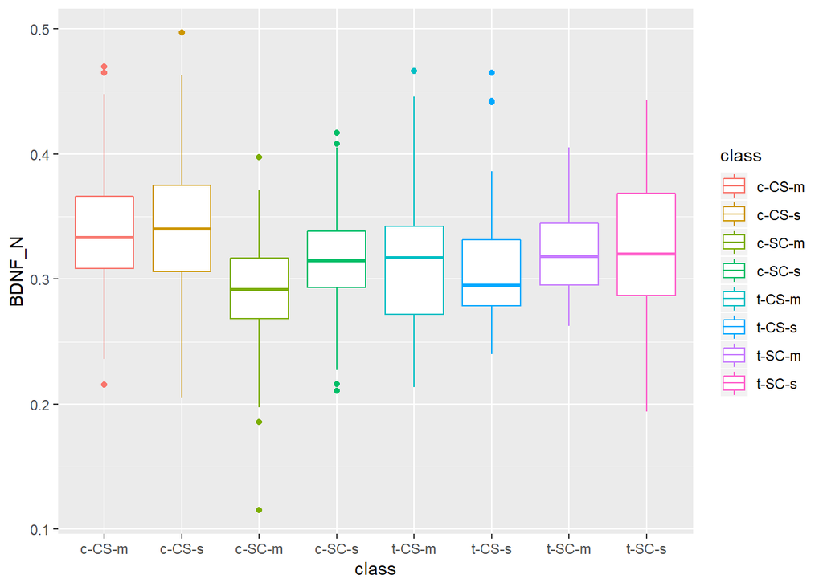

```r
ggplot(data=nucl,aes(x=class,y=BDNF_N,color=class))+geom_boxplot()
```

В совокупности из данных пост-хок теста и графика можем увидеть несколько различий. Например, между контрольными группами context-shock после обработки солью и мемантином разницы нет, тогда как сравнение обеих вариантов контрольных групп context-shock с соответствующими группами shock-context уже показывает значимую разницу в продукции белка.

Теперь построим линейную модель, чтобы…

## Предсказать уровень продукции белка ERBB4_N по данным о других белках

```r
full_lm <- lm(ERBB4_N~.,nucl[,-c(1,79,80,81,82)])
summary(full_lm)
```

```
##
## Call:
## lm(formula = ERBB4_N ~ ., data = nucl[, -c(1, 79, 80, 81, 82)])
##
## Residuals:
##       Min        1Q    Median        3Q       Max
## -0.023037 -0.003370 -0.000127  0.003071  0.031955
##
## Coefficients: (1 not defined because of singularities)
##                   Estimate Std. Error t value Pr(>|t|)
## (Intercept)      2.566e-02  8.245e-03   3.112 0.001970 **
## DYRK1A_N        -6.824e-03  7.475e-03  -0.913 0.361710
## ITSN1_N          8.127e-03  1.058e-02   0.768 0.442776
## BDNF_N           3.833e-02  1.919e-02   1.997 0.046378 *
## NR1_N           -1.409e-02  6.685e-03  -2.108 0.035544 *
## NR2A_N          -1.049e-04  1.361e-03  -0.077 0.938610
## pAKT_N           7.961e-02  3.044e-02   2.615 0.009203 **
## pBRAF_N         -4.103e-02  3.065e-02  -1.339 0.181356
## pCAMKII_N       -1.451e-05  7.954e-04  -0.018 0.985451
## pCREB_N         -6.015e-02  2.910e-02  -2.067 0.039290 *
## pELK_N           4.731e-05  1.030e-03   0.046 0.963391
## pERK_N          -1.987e-02  7.887e-03  -2.519 0.012109 *
## pJNK_N          -6.035e-02  2.538e-02  -2.378 0.017814 *
## PKCA_N           8.377e-03  2.736e-02   0.306 0.759625
## pMEK_N           8.498e-03  2.706e-02   0.314 0.753676
## pNR1_N          -2.566e-02  1.334e-02  -1.924 0.054968 .
## pNR2A_N          1.004e-02  7.239e-03   1.388 0.165927
## pNR2B_N          1.928e-02  6.659e-03   2.896 0.003959 **
## pPKCAB_N         5.727e-03  2.773e-03   2.065 0.039457 *
## pRSK_N           1.001e-02  1.427e-02   0.701 0.483573
## AKT_N           -6.738e-04  8.183e-03  -0.082 0.934413
## BRAF_N           1.550e-02  1.213e-02   1.278 0.201926
## CAMKII_N        -3.429e-03  2.011e-02  -0.170 0.864700
## CREB_N          -1.450e-02  3.091e-02  -0.469 0.639135
## ELK_N            3.510e-03  3.719e-03   0.944 0.345811
## ERK_N            4.660e-03  2.804e-03   1.662 0.097208 .
## GSK3B_N         -5.840e-03  6.824e-03  -0.856 0.392588
## JNK_N           -1.188e-02  3.378e-02  -0.352 0.725317
## MEK_N            8.785e-03  2.197e-02   0.400 0.689510
## TRKA_N           5.722e-03  1.646e-02   0.348 0.728257
```

[output cut: 39 more lines]

```
## BCL2_N           6.173e-03  3.112e-02   0.198 0.842840
## pS6_N                   NA         NA      NA       NA
## pCFOS_N         -1.232e-02  3.111e-02  -0.396 0.692240
## SYP_N            1.354e-02  1.079e-02   1.254 0.210395
## H3AcK18_N        2.401e-03  2.527e-02   0.095 0.924349
## EGR1_N          -6.016e-03  2.619e-02  -0.230 0.818406
## H3MeK4_N         1.227e-02  2.154e-02   0.570 0.569097
## CaNA_N          -1.749e-03  3.419e-03  -0.512 0.609159
## ---
## Signif. codes:  0 '***' 0.001 '**' 0.01 '*' 0.05 '.' 0.1 ' ' 1
##
## Residual standard error: 0.005885 on 476 degrees of freedom
##   (528 observations deleted due to missingness)
## Multiple R-squared:  0.8641, Adjusted R-squared:  0.8427
## F-statistic: 40.37 on 75 and 476 DF,  p-value: < 2.2e-16
```

Как мы видим, в коэффициентах модели присутствует строка NA, а значит мы не можем построить модель не исключив данный коэффициент, так как по видимому он линейно коррелирует с каким-то другим коэффициентом

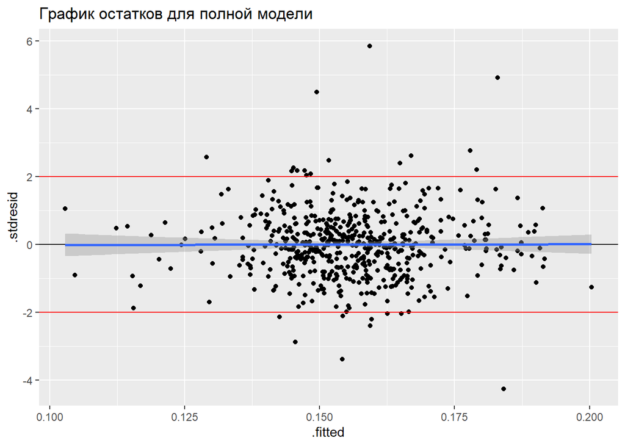

```r
full_2 <- update(full_lm, .~. - pS6_N)
full_lm_for <- data.frame(fortify(full_2))
gg_resid <- ggplot(data = full_lm_for, aes(x = .fitted, y = .stdresid)) +
  geom_point() +
  geom_hline(yintercept = 0) +
  geom_smooth(method = "lm") +
  geom_hline(yintercept = 2, color = "red") +
  geom_hline(yintercept = -2, color = "red") +
  ggtitle("График остатков для полной модели")
gg_resid
```

Гетероскедастичности и нелинейности остатков не видим, но тем не менее есть наблюдения, выходящие из зоны +- 2 стандартных отклонения.

Построим график расстояний кука для оценки наличия влиятельных наблюдений

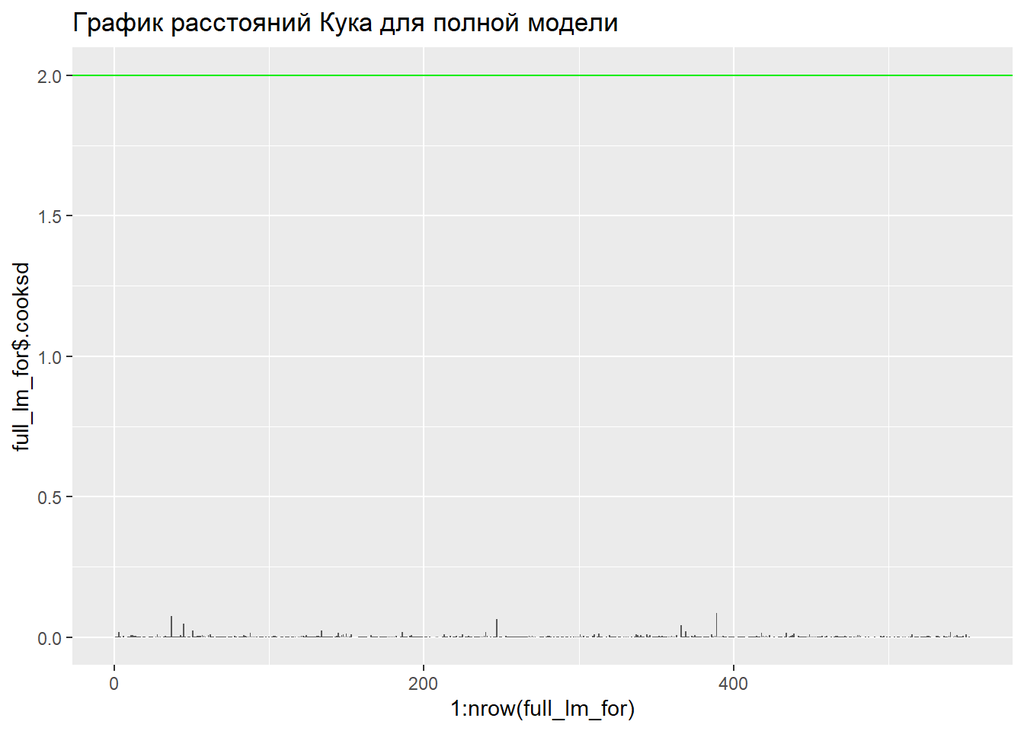

```r
ggplot(, aes(x = 1:nrow(full_lm_for), y = full_lm_for$.cooksd)) +
  geom_bar(stat = "identity") +
  geom_hline(yintercept = 2, color = "green2") + ggtitle("График расстояний Кука для полной модели")
```

Ни одно значение не превышает условного порога в 2 единицы, а значит влиятельных наблюдений нет

А теперь посмотрим как в датасете обстоит дело с мультиколлинеарностью

```r
vif(full_2)
```

```
##        DYRK1A_N         ITSN1_N          BDNF_N           NR1_N          NR2A_N
##       23.736607       59.473637       16.669610       96.311682       25.127918
##          pAKT_N         pBRAF_N       pCAMKII_N         pCREB_N          pELK_N
##       21.880134        9.671403       19.251803       17.421324        2.584965
##          pERK_N          pJNK_N          PKCA_N          pMEK_N          pNR1_N
##       55.739024       26.508561       38.653895       23.634116       44.380168
##         pNR2A_N         pNR2B_N        pPKCAB_N          pRSK_N           AKT_N
##       33.053974       55.826515       33.036076       15.913962       17.993694
##          BRAF_N        CAMKII_N          CREB_N           ELK_N           ERK_N
##       41.690503       16.062122        9.992444       29.844699       55.249434
##         GSK3B_N           JNK_N           MEK_N          TRKA_N           RSK_N
##       32.819856       18.997732       15.629309       72.480935       16.236937
##           APP_N      Bcatenin_N          SOD1_N          MTOR_N           P38_N
##       21.563500       91.994091       20.108411       17.860768       19.953844
##         pMTOR_N         DSCR1_N         AMPKA_N          NR2B_N         pNUMB_N
##       17.905757       14.567686       27.108067       11.017845       20.067495
##        RAPTOR_N         TIAM1_N        pP70S6_N          NUMB_N         P70S6_N
##       19.127590       21.793679        9.784679       23.482651       13.516220
##        pGSK3B_N         pPKCG_N          CDK5_N            S6_N        ADARB1_N
##       12.102837       22.052092        2.976573       17.503666        9.335931
##    AcetylH3K9_N          RRP1_N           BAX_N           ARC_N          nNOS_N
##       42.778299        1.716449        8.071101       14.624584        9.589675
##           Tau_N          GFAP_N         GluR3_N         GluR4_N          IL1B_N
##       17.829428        5.422842       10.719066        8.004983        9.575112
##         P3525_N        pCASP9_N         PSD95_N          SNCA_N     Ubiquitin_N
##        7.896508        9.082792       14.501625        9.291047       10.532632
## pGSK3B_Tyr216_N           SHH_N           BAD_N          BCL2_N         pCFOS_N
##       11.355079        5.101022       13.413137        8.480518        6.364879
##           SYP_N       H3AcK18_N          EGR1_N        H3MeK4_N          CaNA_N
##        9.429731       36.335690       13.981307       15.299243       19.739341
```

## Анализ главных компонент

Для проведения анализа главных компонент воспользуемся пакетом **vegan**. Так же предварительно уберем из датасета неполные наблюдения.

```r
nucl_complete <- nucl[complete.cases(nucl),]
nucl_pca <- rda(nucl_complete[,-c(1,79,80,81,82)], scale = TRUE)
```

Построим график нагрузок с использованием функции **biplot**.

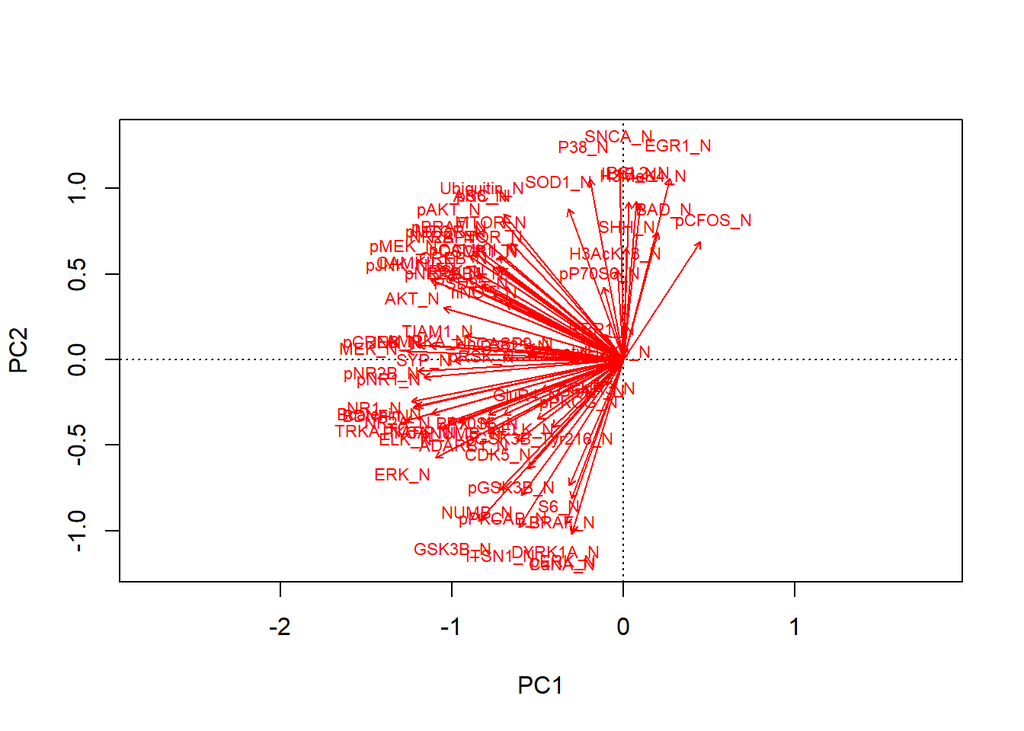

```r
biplot(nucl_pca, scaling = "species", display = "species")
```

В данном случае достаточно сложно выделить какие признаки коррелируют с друг другом, так как углы между векторами примерно одинаковы и никаких хорошо очерченных групп не выделяется.

Теперь построим график ординации, чтобы оценить сходство между наблюдениями в различных группах. Для визуализации воспользуемся пакетом **ggplot2**

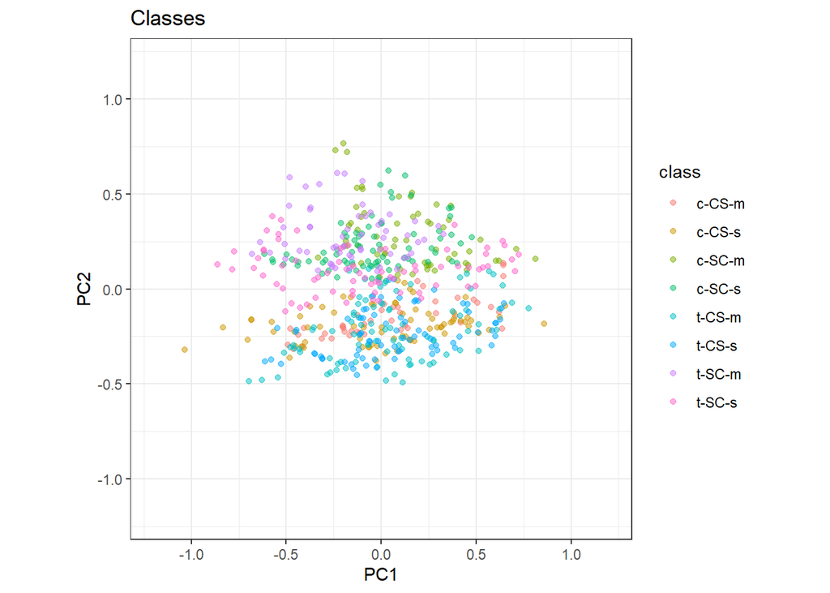

```r
df_scores <- data.frame(nucl_complete,
                        scores(nucl_pca, display = "sites", choices = c(1, 2, 3), scaling = "sites"))


p_scores <- ggplot(df_scores, aes(x = PC1, y = PC2)) +  geom_point(aes( color = class), alpha = 0.5) +coord_equal(xlim = c(-1.2, 1.2), ylim = c(-1.2, 1.2)) + ggtitle(label = "Classes")+theme_bw()
p_scores
```

Как мы видим, четких кластеров для восьми классов выявить также не удается. Попробуем сделать разделения на 2 группы по разным факторам.

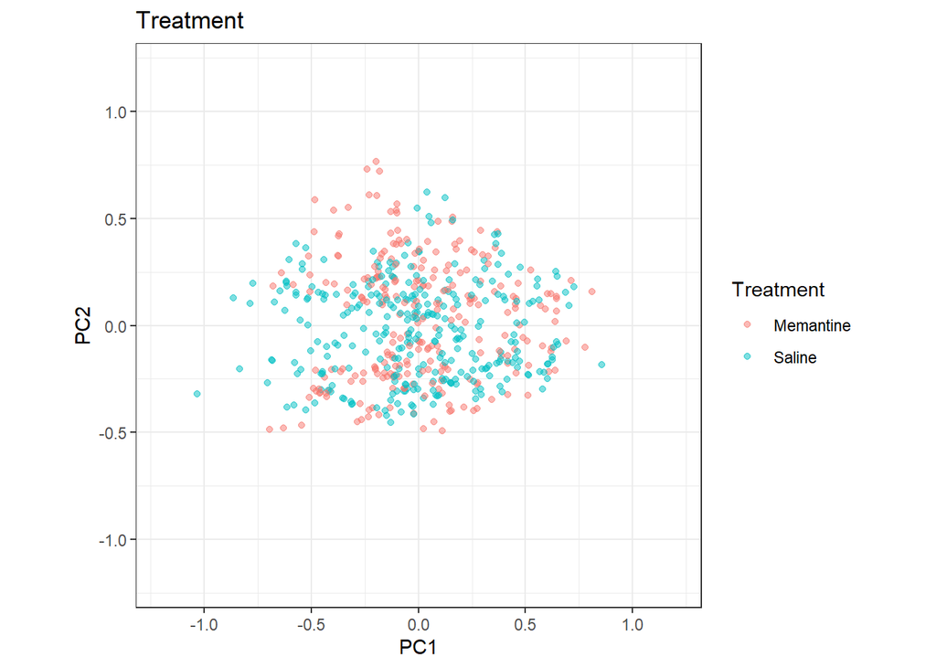

```r
p_scores <- ggplot(df_scores, aes(x = PC1, y = PC2)) +  geom_point(aes( color = Treatment), alpha = 0.5) +coord_equal(xlim = c(-1.2, 1.2), ylim = c(-1.2, 1.2)) + ggtitle(label = "Treatment")+theme_bw()
p_scores
```

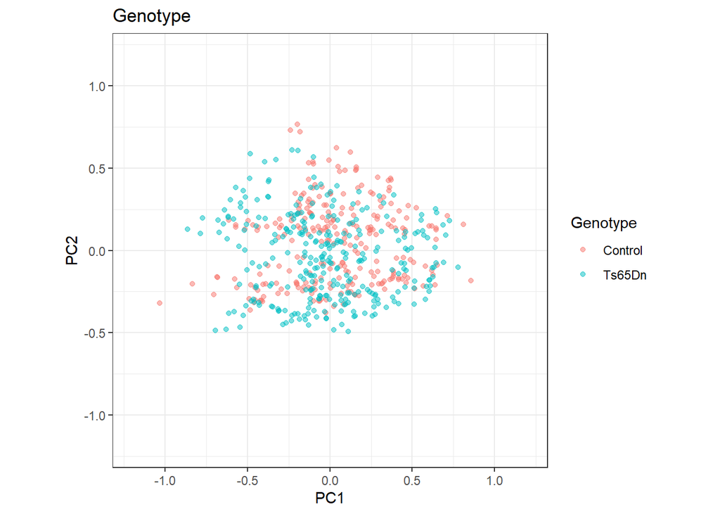

```r
p_scores <- ggplot(df_scores, aes(x = PC1, y = PC2)) +  geom_point(aes( color = Genotype), alpha = 0.5) +coord_equal(xlim = c(-1.2, 1.2), ylim = c(-1.2, 1.2)) + ggtitle(label = "Genotype")+theme_bw()
p_scores
```

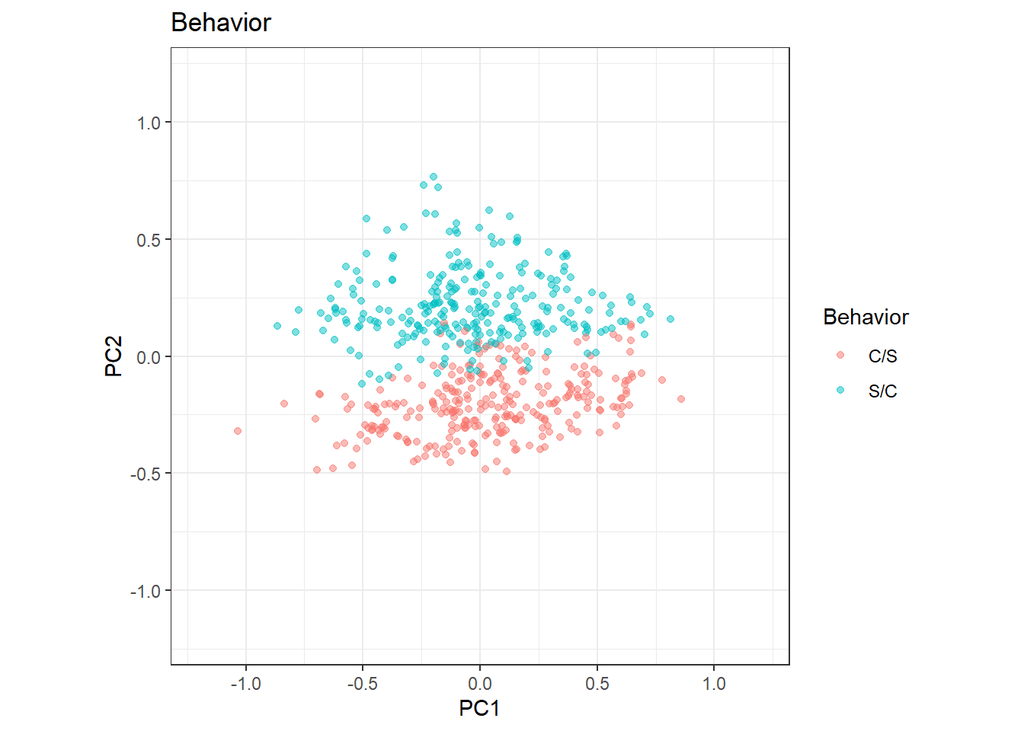

```r
p_scores <- ggplot(df_scores, aes(x = PC1, y = PC2)) +  geom_point(aes( color = Behavior), alpha = 0.5) +coord_equal(xlim = c(-1.2, 1.2), ylim = c(-1.2, 1.2)) + ggtitle(label = "Behavior")+theme_bw()
p_scores
```

Как мы видим, во всех группах при делении на 2 класса данные также плохо расходятся, но в поведении видим хорошую кластеризацию. То есть именно этот фактор особенно интересен для дальнейшего изучения один, а не в совокупности.

Посмотрим, какой вклад вносит каждая из компонент. Для этого визализируем результаты summary PCA анализа с помощью barplot

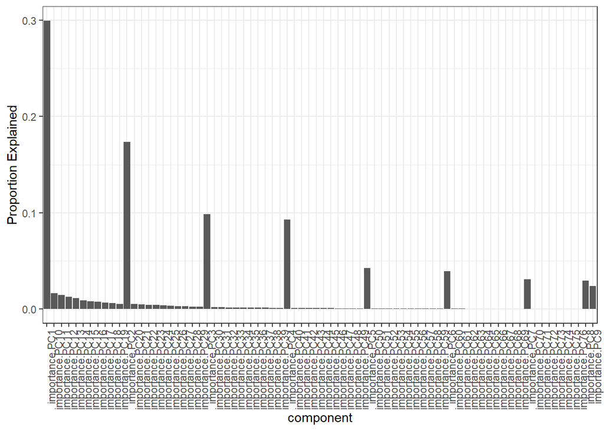

```r
pca_summary <- summary(nucl_pca)
pca_result <- as.data.frame(pca_summary$cont)
plot_data <- as.data.frame(t(pca_result[c("Proportion Explained"),]))
plot_data$component <- rownames(plot_data)

ggplot(plot_data, aes( component, `Proportion Explained`)) + geom_bar(stat = "identity") + theme_bw()+theme(axis.text.x = element_text(angle = 90, hjust = 1))
```

Видим, что действительно самый большой процент объясняет компонента PC1, а дальше уже идет вклад PC2 и т.д. Тем не менее вклад PC3 от PC4 уже сильно не различается.